## # Lab4 Answers File

## Please write your answers into the space below the questions. Knit this file when you are done to check that all code runs. Remember to rename the file to contain *your actual* Last and First name and **submit both the Rmd and Html file to canvas**.

#### Amatullah Mir

**1)** The probability of a healthy person staying healthy the next day is 0.79, and the probability of an infected person remaining infected the next day is 0.83.

**2**

```r
days<-365
CURstate<-0 #Let's represent the healthy state with 0 and the infected state with 1
state<-numeric(days)
for(i in 1:days){
  randomNum<-runif(1)  #runif(1) randomly generates a number between 0 and 1
  if(CURstate==0){
    if(randomNum < .21){
      CURstate <- 1
    }else{
      CURstate <- 0
    }
  }else{
    if(randomNum < .17){
      CURstate<-0
    }else{
      CURstate<-1
    }
  }
  state[i]<-CURstate
}
state
```

```
##   [1] 0 1 1 0 1 1 0 0 0 0 0 0 1 1 1 1 1 1 1 1 1 1 0 0 0 1 1 1 1 1 1 0 1 0 0 0 0
##  [38] 0 0 0 0 0 0 0 1 1 1 1 1 0 1 1 1 1 1 1 0 0 0 0 0 1 1 1 1 1 1 1 1 1 1 1 1 1
##  [75] 1 0 0 1 1 1 0 0 0 0 0 0 0 1 1 1 1 1 1 1 1 1 1 1 0 0 0 0 0 1 0 0 0 0 0 0 0
## [112] 0 0 0 0 1 1 1 0 0 0 0 0 0 0 0 0 1 1 0 1 1 1 1 1 1 0 0 0 0 0 0 0 0 0 1 1 1
## [149] 1 0 1 1 1 0 0 0 0 1 1 1 1 1 0 1 1 1 1 1 0 0 0 0 0 0 0 0 1 1 1 1 1 0 0 1 1
## [186] 1 1 0 0 0 1 1 1 0 0 0 0 0 0 0 0 0 0 0 0 1 0 1 1 1 0 0 0 0 0 1 1 1 1 1 1 1
## [223] 1 1 1 1 1 1 1 1 1 0 0 0 0 1 0 0 0 0 0 1 1 1 0 0 0 0 0 0 0 0 0 0 0 0 0 0 1
## [260] 1 1 1 1 1 0 0 0 0 0 0 0 1 1 1 0 0 0 1 1 1 0 0 1 0 0 0 0 0 0 0 0 0 0 0 1 1
## [297] 1 1 1 1 1 1 0 0 1 1 1 1 1 1 0 0 0 0 0 0 0 1 1 1 0 1 1 1 1 1 1 1 1 1 1 1 1
## [334] 1 1 1 1 1 0 0 0 0 1 1 1 1 0 0 1 1 1 0 0 0 0 0 0 0 0 0 0 0 0 0 1
```

line 1: here we assign a variable “days” as 365, to represent the number of days in a year.

line 2: CURstate is another variable that is representative of the state of an individual (healthy/infected).

line 3: this line directs the program to view the state as a variable representing the number of days as a numeric variable/interpret the value as a number.

line 4: starting at this line, we are setting up a loop to generate a function that prints out 365 values of both infected and healthy individuals. This first line sets up the loop to run the test between 1 and the number of days, in this case 365.

line 5: randomNum is a variable assignment to the runif function, which will generate a random number from 0 to 1.

line 6: If the numeric value of CURstate is equal to 0, then the next code will run:

line 7: This line will check to see if the randomNum generated is less than 0.21.

line 8: If it is, then CURstate will be “1”

line 9: If not,

line 10: then CURstate will be “0”

line 11: bracket

line 12: If CURstate is not equal to 0, then the following function will be run:

line 13: This line will check to see if the randomNum generated is less than 0.17.

line 14: If it is, then CURstate will be “0”

line 15: If not,

line 16: Then CURstate will be “1”

line 17: bracket

line 18: bracket

line 19: This line takes the values for CURstate and assigns them to each i in state.

line 20: bracket

line 21: This line returns the values of state.

** The purpose of runif is to generate a random individual’s probability between 0 and 1 to determine their status as healthy or infected. The use of 0.21 is to determine whether or not an individual is infected, since the probability of becoming infected the next day if you are healthy is 0.21. ***

**3**

```r
days<-365
CURstate<-1 # Let's represent the healthy state with 0 and the infected state with 1
state<-numeric(days)
for(i in 1:days){
  randomNum<-runif(1)  # runif(1) randomly generates a number between 0 and 1
  if(CURstate==0){
    if(randomNum < .21){
      CURstate <- 1
    }else{
      CURstate <- 0
    }
  }else{
    if(randomNum < .17){
      CURstate<-0
    }else{
      CURstate<-1
    }
  }
  state[i]<-CURstate
}
state
```

```
##   [1] 1 1 0 0 0 1 0 0 0 0 0 0 0 0 0 0 0 0 0 0 0 0 0 0 0 0 0 0 0 0 0 0 0 0 0 0 0
##  [38] 0 0 0 0 0 1 1 1 0 0 1 1 1 1 1 1 1 1 1 1 1 1 1 1 1 1 0 0 1 0 0 0 0 1 1 1 0
##  [75] 1 1 1 1 0 0 0 0 0 0 0 0 1 1 1 1 1 1 1 1 1 1 1 1 1 1 1 0 0 0 1 1 1 0 0 0 0
## [112] 1 1 1 1 0 1 1 0 0 0 0 0 0 0 0 0 0 0 0 0 0 0 0 1 1 1 1 1 1 1 1 1 1 0 0 0 1
## [149] 1 1 1 1 1 1 1 1 1 1 1 1 1 1 1 1 1 1 0 0 0 0 0 1 1 1 1 1 1 0 0 0 0 0 0 0 0
## [186] 0 0 1 1 1 1 1 1 1 1 1 0 0 0 0 0 0 0 0 0 1 1 1 1 0 1 1 1 1 0 0 0 0 0 0 0 1
## [223] 1 1 1 1 1 0 0 0 0 0 0 0 0 1 1 1 1 1 1 1 1 0 0 0 1 1 1 1 1 1 1 1 0 1 1 1 1
## [260] 1 1 1 1 0 1 1 1 1 1 1 1 0 1 1 1 1 1 1 1 1 1 1 1 1 1 1 1 1 1 1 0 0 0 1 0 1
## [297] 1 1 0 0 0 0 0 1 1 1 0 1 1 0 1 1 1 1 1 1 1 1 1 1 1 1 1 1 1 1 1 0 0 0 0 0 1
## [334] 1 1 1 1 1 1 1 1 0 0 0 0 0 0 0 1 0 0 0 0 1 1 1 1 1 1 1 1 1 1 1 1
```

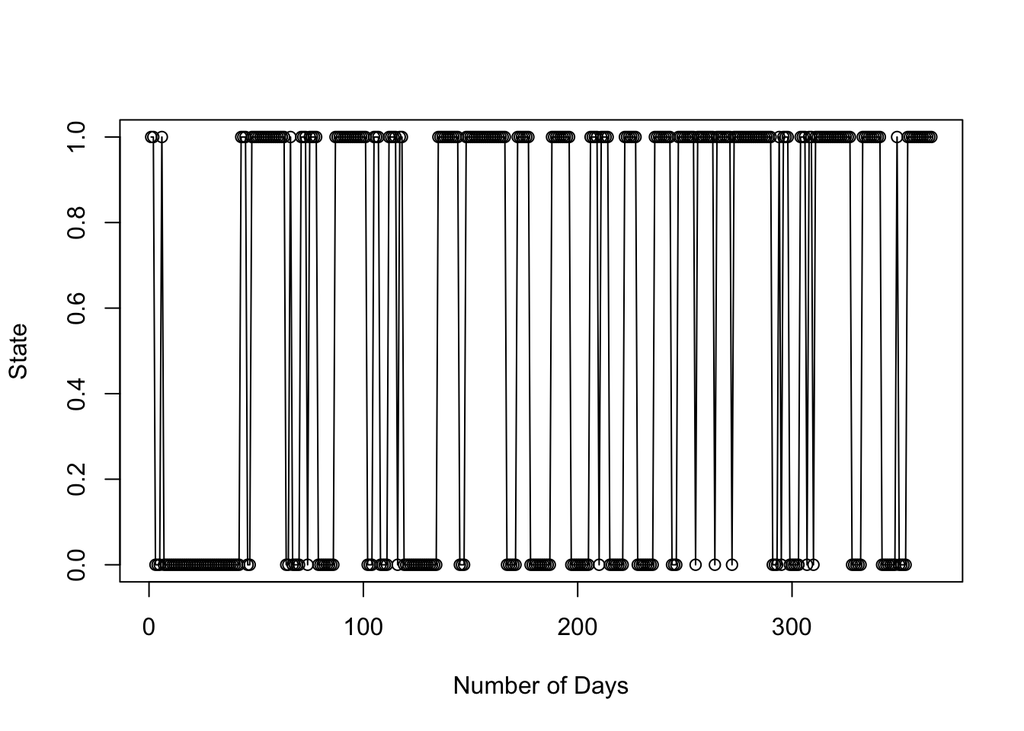

```r
plot(1:365, state, xlab = "Number of Days", ylab = "State", type = "o")
```

The points are either 1 or 0. We can see how many points are at 0 or 1 in order to determine the days they spend while healthy or infected. The lines show the transition between being healthy and being infected. Generally speaking, there are even amounts of time spent being healthy and infected, and there are multiple transitions.